# Crime Report DB in Postgresql

Objectives:

- Create a database `crimes_db` with a table `boston_crimes` with appropriate data types
- Create a schema and create the table inside it
- Loading the data from `boston.csv` in the table
- Create `readonly` and `readwrite` groups with appropriate privileges
- Create users for each of the groups

### Create DB and Schema

```python
# Read user_name and password from Envirenmental Variables in .env file
from dotenv import load_dotenv
import os

load_dotenv()

username = os.environ.get('user_name')
pwd = os.environ.get('password')
```

```python
# Import library and create the DB and close the connection
import psycopg2

connection_str = "user={} password={} host=127.0.0.1 port=5432 dbname=DB".format(username,pwd)

conn = psycopg2.connect(connection_str)
cur = conn.cursor()
# set autocommit to True bacause this is required for creating databases
# CREATE DATABASE can only be executed as a single
conn.autocommit = True

cur.execute("CREATE DATABASE crimes_db;")
conn.close()
```

```python
connection_str = "user={} password={} host=127.0.0.1 port=5432 dbname=crimes_db".format(username,pwd)
conn = psycopg2.connect(connection_str)
cur = conn.cursor()

# Create a Schema in DB
cur.execute("CREATE SCHEMA crimes;")
```

```python
# Let's Check Schema and DBs
qu_schema = """SELECT schema_name
                FROM information_schema.schemata;
            """
cur.execute(qu_schema)
schema_name = cur.fetchall()

cur.execute("SELECT current_database();")
dbname = cur.fetchall()

print("Schema name  = {} \n DB name = {}".format(schema_name, dbname))
```

```
Schema name  = [('pg_toast',), ('pg_temp_1',), ('pg_toast_temp_1',), ('pg_catalog',), ('information_schema',), ('public',), ('crimes',)]
 DB name = [('crimes_db',)]
```

### Obtain Column Names and Sample

```python
import csv
with open('boston.csv', 'r') as f:
    reader = csv.reader(f)
    col_headers = next(reader)
    first_row = next(reader)

with open('boston.csv', 'r') as f:
    rows = list(f)
    for idx, row in enumerate(rows[:3], start=1):
        print(idx, row, sep='\t')

print("Number of rows in the file excluding header = {}".format(len(rows)-1))
```

[output not shown]

### Helper function to analyze column values

Create a function `get_col_set` that returns a set of all distinct values of a column by passing in CSV file name and column index

Helps to see if the column is categorical with limited set of values (To use a Enumerated datatype) and check the max length of charactes in a column

```python
def get_col_set(csv_file, col_idx):
    import csv

    with open(csv_file, 'r') as f:
        next(f)
        reader = csv.reader(f)
        col_set = set()
        for row in reader:
            col_set.add(row[col_idx])
    return col_set
```

```python
for col in range(len(col_headers)):
    values = get_col_set("boston.csv", col)
    print(col_headers[col], len(values), sep='\t')
```

```
incident_number	298329
offense_code	219
description	239
date	1177
day_of_the_week	7
lat	18177
long	18177
```

### Analyzing the maximum length or value range

- `description` and `day_of_the_week` are textual columns
- Longest text in `day_of_the_week` must be Wednesday but we need to compute that for the other column

```python
col_headers
```

```
['incident_number',
 'offense_code',
 'description',
 'date',
 'day_of_the_week',
 'lat',
 'long']
```

```python
# Max characters
desc_set = get_col_set("boston.csv", 2)

max_len = max(desc_set, key=len)
len(max_len)
```

```
58
```

- Lat and Long columns have typically 8 digits after decimal and 2 before

```python
# Max Precision and Scale
long_set = get_col_set("boston.csv", 6)

max_len = max(long_set, key=len)
max_len
```

```
'-71.14678737'
```

```python
lat_set = get_col_set("boston.csv", 5)
max_dig = max(lat_set, key=len)
max_dig
```

```
'42.29297429'
```

- Check the maximum value in `offense_code` and distribution to decide whether `smallint` is big enough for this column

```python
# Max value and distribution
with open("boston.csv", 'r') as f:
    next(f)
    reader = csv.reader(f)
    col = []
    for row in reader:
        col.append(int(row[1]))

max(col)
```

```
3831
```

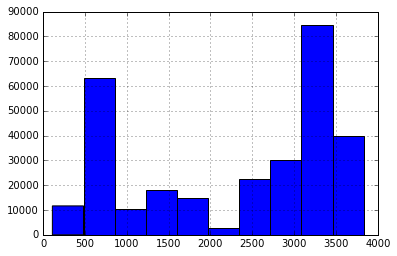

```python
import pandas as pd
%matplotlib inline

pd.Series(col).hist()
```

### Creating the table

**Table Datatypes:**

For `incident_number` could contain big numbers as the table grows so `numeric` useful as it has variable byte size. It is also set as the primary key.

`offense_code` are positive integer with 4 digits maximum, so `smallint` with 2 byte would be suitable.

`description` is textual and maximum 58 characters so `varchar(n)` with size 100 so we leave some margin while not wasting extra memory.

For `day_of_the_week`, we created a Enum type called `week` because there are only seven possible values.

The date was represented as the `DATE` datatype. `lat` and `long` both have 8 digits after decimal and two before so I chose `Decimal(10,8)`

```python
# First create the Enum datatype

qu_enum = """
    CREATE TYPE week AS ENUM (
    'Friday', 'Monday', 'Saturday',
    'Sunday', 'Thursday', 'Tuesday',
    'Wednesday'
)"""

cur.execute(qu_enum)
conn.commit()
```

```python
# Create the table

qu_table = """
    CREATE TABLE crimes.boston_crimes (
    incident_number numeric PRIMARY KEY,
    offense_code smallint,
    description VARCHAR(100),
    date date,
    day_of_the_week week,
    latitude decimal(10,8),
    longitude decimal(10,8)
);"""

cur.execute(qu_table)
conn.commit()
```

### Load the csv file into the table

I used `copy_expert` method to load the data which is fast and easy to use.

```python
# Load the data from boston.csv into boston_crimes table in the crimes schema

with open('boston.csv', 'r') as f:
    cur.copy_expert("COPY crimes.boston_crimes FROM STDIN WITH CSV HEADER;", f)
```

```python
# print number of rows to ensure that they were loaded
# Number of rows in the file excluding header = 298329

cur.execute("SELECT * FROM crimes.boston_crimes;")
print(len(cur.fetchall()))
```

```
298329
```

### Creating groups and handling privileges

- To avoid privilege inheretance from public group, we revoke all privileges from it
- Next, we create groups with suitable privileges and add users to groups so this way we don't need to permitt of revoke for each user individually. (Users inherite privileges from their groups)
- Lastly, create users and assign to the groups with privileges suitable for the user

#### Revoke public privileges

We revoke all privileges of the public public group on the public schema to ensure that users will not inherit privileges on that schema such as the ability to create tables in the public schema.

```python
cur.execute("REVOKE ALL ON SCHEMA public FROM public;")
cur.execute("REVOKE ALL ON DATABASE crimes_db FROM public;")

conn.commit()
```

#### Create Readonly Group

```python
# Create readonly and readwrite groups
cur.execute("CREATE GROUP readonly NOLOGIN;")

# Grant Connection privilege to both so they could connect to DB
cur.execute("GRANT CONNECT ON DATABASE crimes_db TO readonly;")

# Grant Usage privilege to both for using tables in a Schema
cur.execute('GRANT USAGE ON SCHEMA crimes TO readonly;')

# Only SELECT for readonly
cur.execute('GRANT SELECT ON ALL TABLES IN SCHEMA crimes TO readonly;')

conn.commit()
```

#### Create Readwrite Group

```python
cur.execute("CREATE GROUP readwrite  NOLOGIN;")
cur.execute("GRANT CONNECT ON DATABASE crimes_db TO readwrite;")
cur.execute('GRANT USAGE ON SCHEMA crimes TO readwrite;')
cur.execute('GRANT INSERT, SELECT, DELETE, UPDATE ON ALL TABLES IN SCHEMA crimes TO readwrite;')

conn.commit()
```

#### Creat one user for each of the groups

```python
# CREATE Users and assign to appropriate groups
cur.execute("CREATE USER data_analyst WITH PASSWORD 'secret1';")
cur.execute("GRANT data_analyst TO readonly;")

cur.execute("CREATE USER data_scientist WITH PASSWORD 'secret2';")
cur.execute("GRANT data_scientist TO readwrite;")

conn.commit()
```

### Test Database Setup

Test the DB setup using SQL queries on the `pg_user`, `pg_roles` and `information_schema.table_privileges` tables.

In `information_schema.table_privileges` table I will check privileges realted to type of SQL queries on the table. I will list the group name and the SQL queries, users in each group are allowed to make.

```python
# Helper function to fetch and print in readable format
def fetch_all(cursor):
    values = cursor.fetchall()
    for value in values:
        print(value)
    print('\n')
    return values
```

Here are description of each value in the result of query on `pg_user` table

**pg_user** [documentation](https://www.postgresql.org/docs/current/view-pg-user.html)

- From Left to right:
  - usename
  - ID of this user
  - User can create databases
  - User is a superuser
  - User can initiate streaming replication
  - User bypasses every row-level security policy
  - password
  - Password expiry time
  - Session defaults for run-time configuration variables

```python
# Let's Check the users and privileges from "pg_user" and "information_schema.table_privileges"
cur.execute("""
    SELECT *
    FROM pg_user
    WHERE usename IN ('data_analyst', 'data_scientist');
""")
users = fetch_all(cur)

# Privileges realted to readonly and readwrite groups
cur.execute('''SELECT grantor, grantee, privilege_type
                FROM information_schema.table_privileges
                WHERE grantee IN ('readonly', 'readwrite');''')
privil = fetch_all(cur)
```

```
('data_analyst', 16413, False, False, False, False, '********', None, None)
('data_scientist', 16414, False, False, False, False, '********', None, None)


('dq', 'readwrite', 'INSERT')
('dq', 'readwrite', 'SELECT')
('dq', 'readwrite', 'UPDATE')
('dq', 'readwrite', 'DELETE')
('dq', 'readonly', 'SELECT')
```

Here are description of what each value means in the result from `pg_roles` table

**pg_roles** [documentation](https://www.postgresql.org/docs/current/view-pg-roles.html)

- From Left to right:
  - Role name
  - Role has superuser privileges
  - Role automatically inherits privileges of roles it is a member of
  - Role can create more roles
  - Role can create databases
  - Role can log in
  - ...
  - ID of role

```python
# Here I check "pg_roles" (It shows both users and groups)
cur.execute("""
    SELECT *
    FROM pg_roles
    WHERE rolname IN ('readonly', 'readwrite', 'data_analyst', 'data_scientist');
""")

pg_roles = fetch_all(cur)

# Privileges realted to boston_crimes table
cur.execute('''SELECT grantor, grantee, privilege_type
                FROM information_schema.table_privileges
                WHERE table_name = 'boston_crimes';''')
privil_table = fetch_all(cur)
```

```
('readonly', False, True, False, False, False, False, False, -1, '********', None, None, 16411)
('readwrite', False, True, False, False, False, False, False, -1, '********', None, None, 16412)
('data_analyst', False, True, False, False, False, True, False, -1, '********', None, None, 16413)
('data_scientist', False, True, False, False, False, True, False, -1, '********', None, None, 16414)


('dq', 'dq', 'INSERT')
('dq', 'dq', 'SELECT')
('dq', 'dq', 'UPDATE')
('dq', 'dq', 'DELETE')
('dq', 'dq', 'TRUNCATE')
('dq', 'dq', 'REFERENCES')
('dq', 'dq', 'TRIGGER')
('dq', 'readwrite', 'INSERT')
('dq', 'readwrite', 'SELECT')
('dq', 'readwrite', 'UPDATE')
('dq', 'readwrite', 'DELETE')
('dq', 'readonly', 'SELECT')
```